# Predicting used car prices with linear regression

Glenn Bruns

April 5, 2018

```r
> set.seed(123)
```

We will use the Kuipers 2008 used car data to try to predict the price of a used car from features like mileage, engine size, and trim.

```r
> #@ 1
> source("lin-regr-util.R")
```

```r
> #@ 2
> cars <- read.csv("https://raw.githubusercontent.com/grbruns/cst383/master/kuiper-2008-cars.csv")
```

```r
> # notes:
> #  - mileage means total number of miles
> #  - R treats factors as indicator variables, automatically
>
> # turn Doors into an indicator variable
> cars$FourDoor = as.numeric(cars$Doors == 4)
> cars$Doors = NULL
>
> # turn Cylinder into an indicator variable
> cars$cyl6 = as.numeric(cars$Cylinder == 6)
> cars$cyl8 = as.numeric(cars$Cylinder == 8)
> cars$Cylinder = NULL
>
> # turn Type into indicator variable (use all but one to avoid correlation)
> cars$Convertible = as.numeric(cars$Type == "Convertible")
> cars$Coupe = as.numeric(cars$Type == "Coupe")
> cars$Hatchback = as.numeric(cars$Type == "Hatchback")
> cars$Sedan = as.numeric(cars$Type == "Sedan")
> cars$Type = NULL
>
> # don't need make as it is implied by Model, but put
> # Make at the front of Model
> cars$Model = paste(cars$Make, cars$Model)
> cars$Make = NULL
```

### Data exploration

In a real project to predict used car prices, we would spend substantial effort on pre-processing and exploring our data. Here we show only scatter plots of a few features.

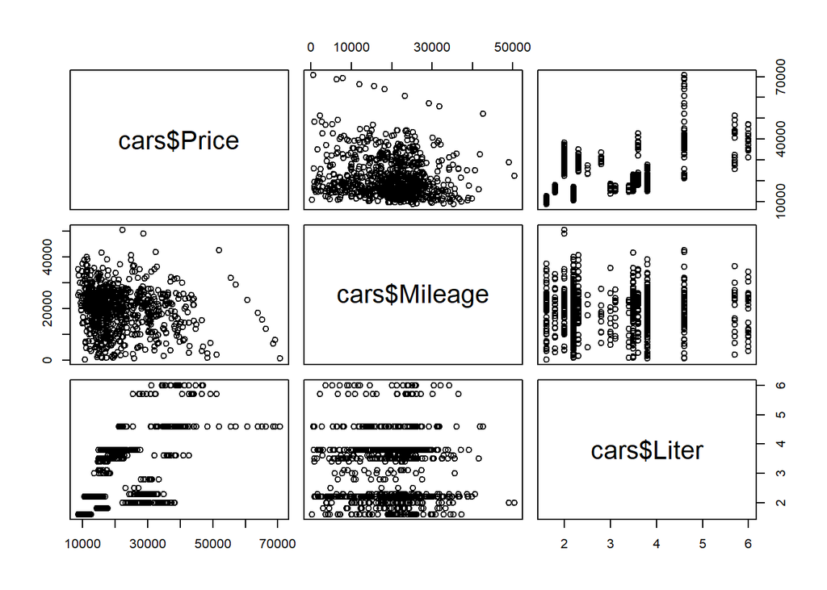

```r
> #@ 3
> pairs(~ cars$Price + cars$Mileage + cars$Liter)
```

### Simple linear regression to predict Price from Mileage

Let’s try predicting price from a car’s mileage, which means the number of miles the car has been driven.

```r
> #@ 4
> fit = lm(Price ~ Mileage, data = cars)
```

The fit shows decreasing price with increasing mileage, as we expect. However, the scatterplot shows we can’t expect too much from using mileage along.

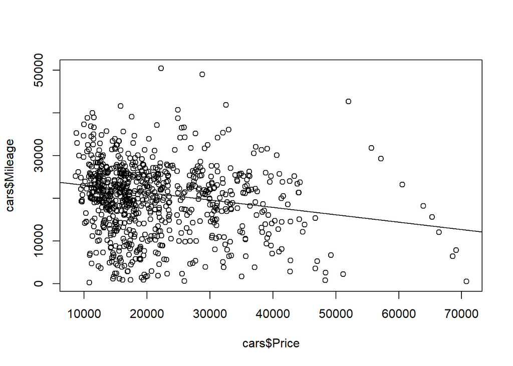

```r
> #@ 5
> plot(cars$Price, cars$Mileage)
> abline(fit)
```

Summary information from the model fit shows large error and a small R-squared statistic.

```r
> # the summary of the fit shows high error
> summary(fit)
```

```
Call:
lm(formula = Price ~ Mileage, data = cars)

Residuals:
   Min     1Q Median     3Q    Max
-13905  -7254  -3520   5188  46091

Coefficients:
              Estimate Std. Error t value Pr(>|t|)
(Intercept)  2.476e+04  9.044e+02  27.383  < 2e-16 ***
Mileage     -1.725e-01  4.215e-02  -4.093 4.68e-05 ***
---
Signif. codes:  0 '***' 0.001 '**' 0.01 '*' 0.05 '.' 0.1 ' ' 1

Residual standard error: 9789 on 802 degrees of freedom
Multiple R-squared:  0.02046,   Adjusted R-squared:  0.01924
F-statistic: 16.75 on 1 and 802 DF,  p-value: 4.685e-05
```

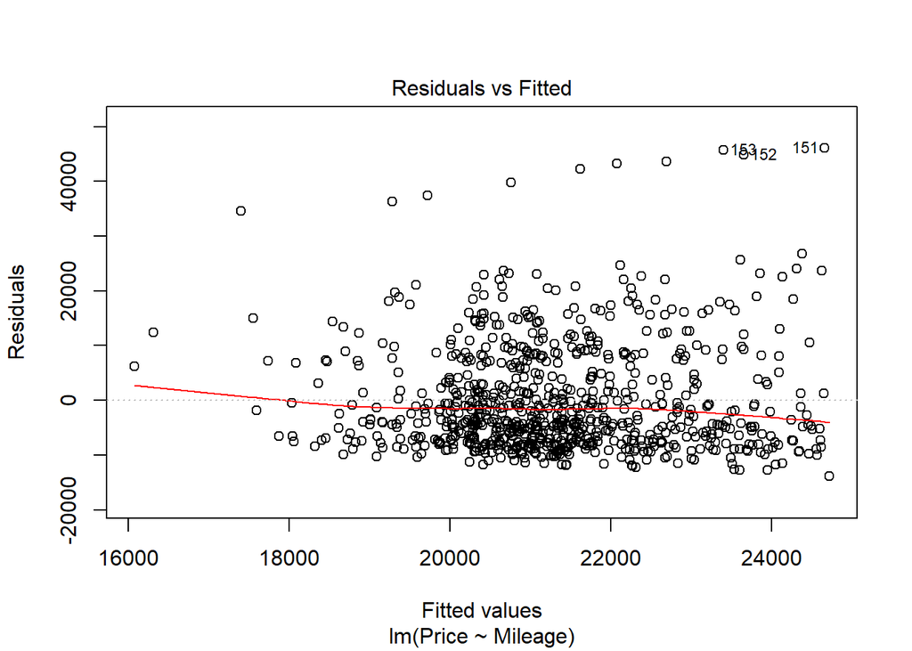

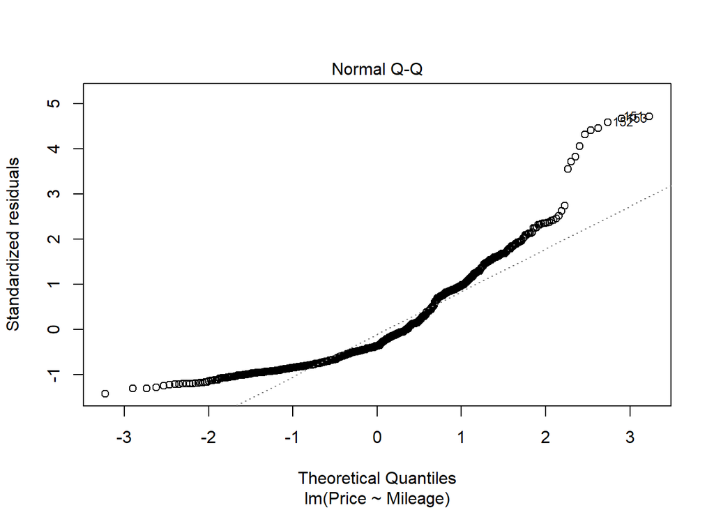

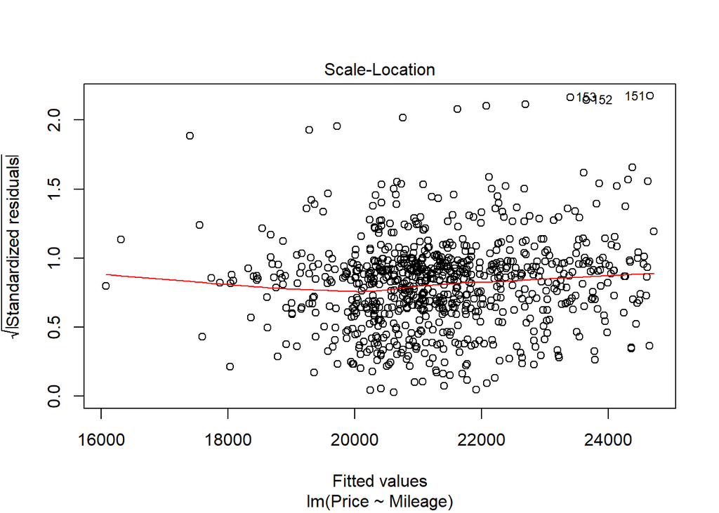

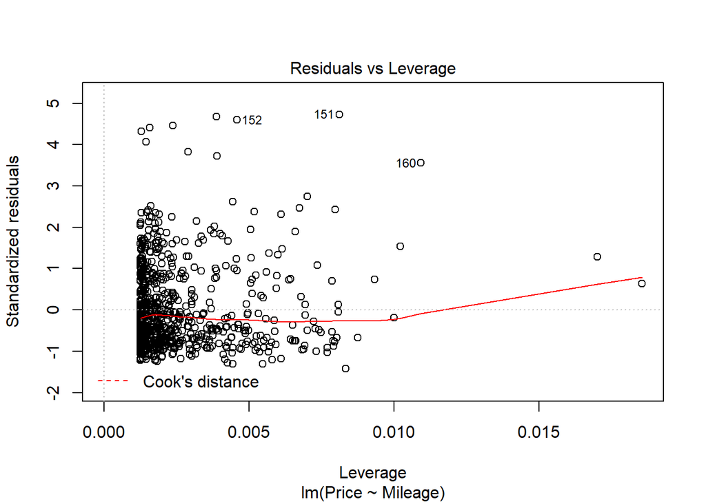

```r
> # plots of the fit show that the distribution of residuals is
> # not too far from a normal distribution
> plot(fit)
```

### Predicting price from Mileage, Cruise, and Leather

We expand the model by incorporating whether a car has a leather interior and cruise control.

```r
> #@ 6
> fit2 <- lm(Price ~ Mileage + Cruise + Leather, data = cars)
```

```r
> # R-squared statistic is not good, but better
> summary(fit2)
```

```
Call:
lm(formula = Price ~ Mileage + Cruise + Leather, data = cars)

Residuals:
   Min     1Q Median     3Q    Max
-17866  -5011   -972   4018  42135

Coefficients:
              Estimate Std. Error t value Pr(>|t|)
(Intercept)  1.430e+04  1.083e+03  13.206  < 2e-16 ***
Mileage     -1.863e-01  3.706e-02  -5.026 6.19e-07 ***
Cruise       1.026e+04  7.053e+02  14.542  < 2e-16 ***
Leather      4.176e+03  6.806e+02   6.135 1.34e-09 ***
---
Signif. codes:  0 '***' 0.001 '**' 0.01 '*' 0.05 '.' 0.1 ' ' 1

Residual standard error: 8606 on 800 degrees of freedom
Multiple R-squared:  0.2448,    Adjusted R-squared:  0.242
F-statistic: 86.46 on 3 and 800 DF,  p-value: < 2.2e-16
```

Plots of predicted vs. actual prices help in showing how the model does overall, and also whether the error is constant or not. In these plots we see that error tends to be bigger when the price is higher.

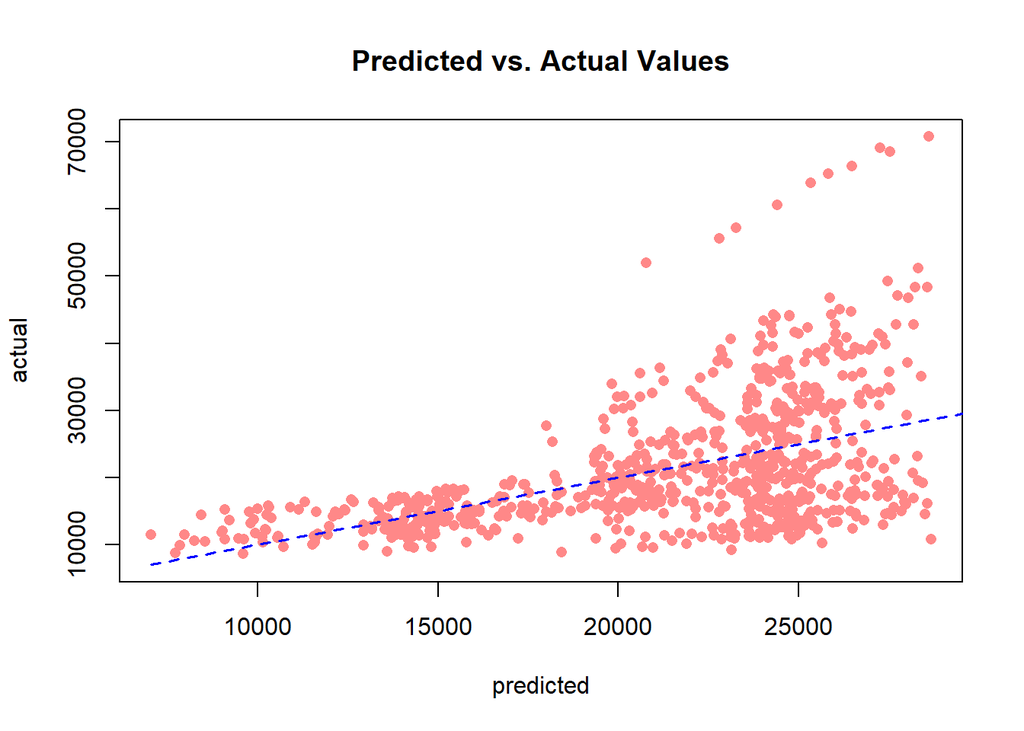

```r
> #@ 7
> predicted <- predict(fit2, cars)
> actual <- cars$Price
> rng <- range(c(predicted,actual))
> plot(actual ~ predicted, pch = 16, col = "#FF8888", ylim = rng, main = "Predicted vs. Actual Values")
> lines(c(rng[1], rng[2]),c(rng[1], rng[2]),lty=2, col="blue", lwd=1.5)
```

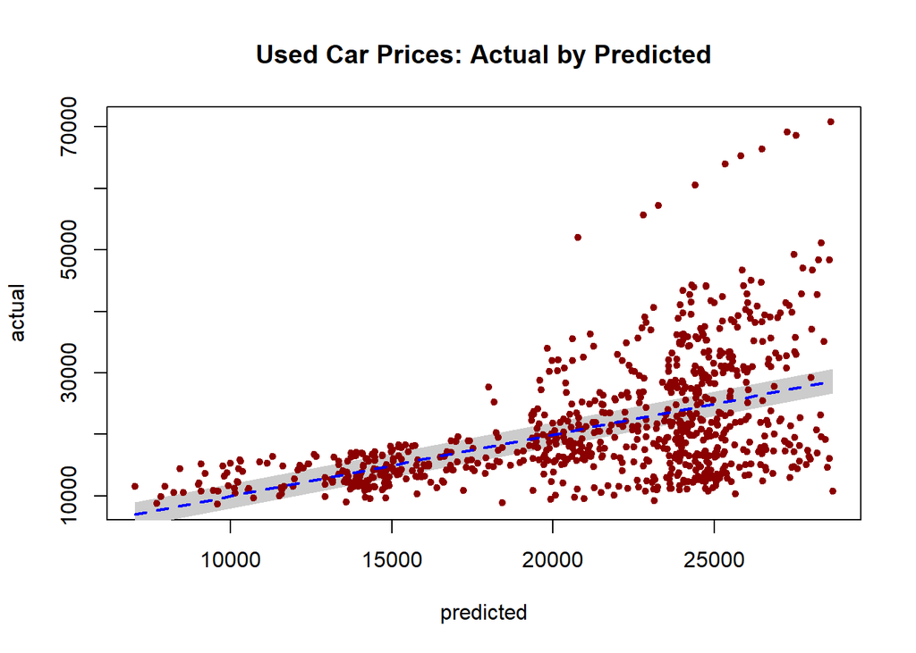

```r
> #@ 8
> plot_predict_actual(predicted,actual, 2000, "Used Car Prices: Actual by Predicted")
```

The Residuals vs Fitted plot is another way of seeing how errors increase with price. This tells us our linear model is not very good yet. The Q-Q plot shows that the distrbution of errors is not too far from a normal distribution.

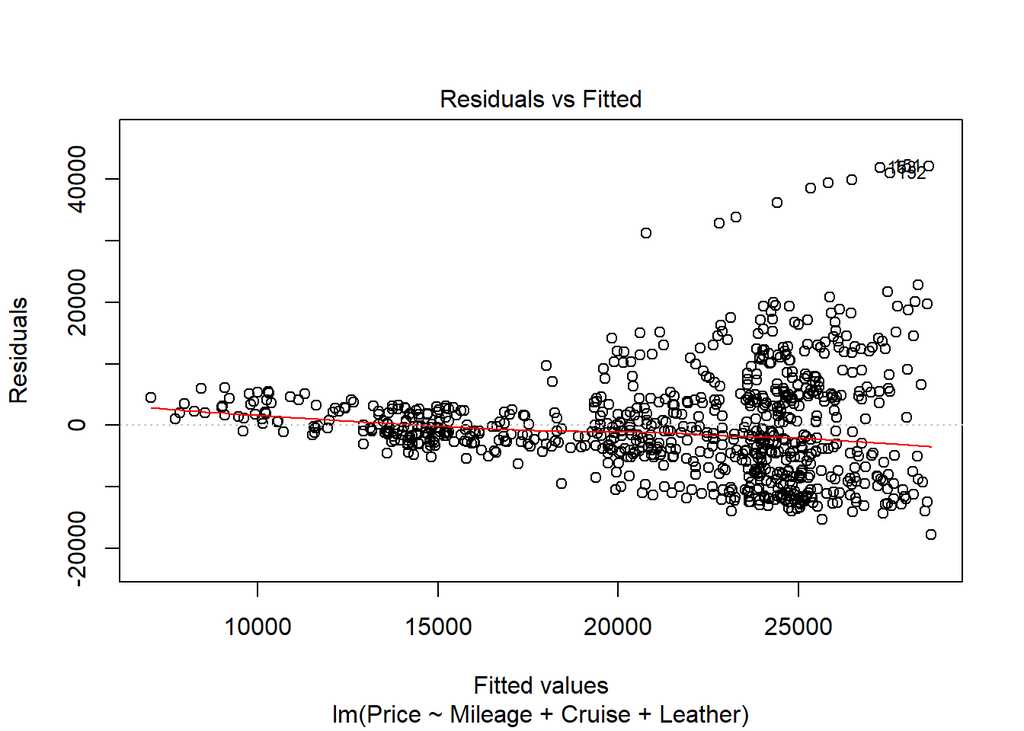

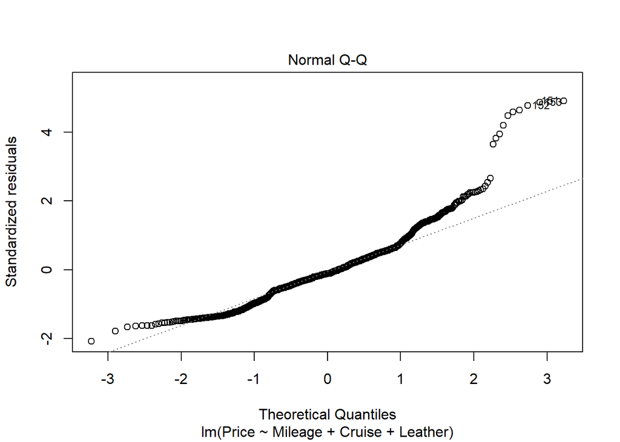

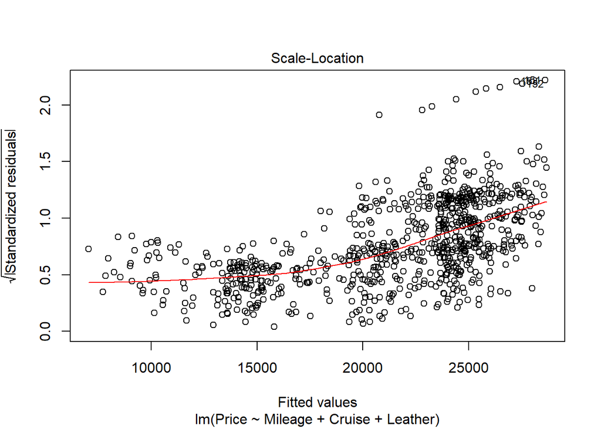

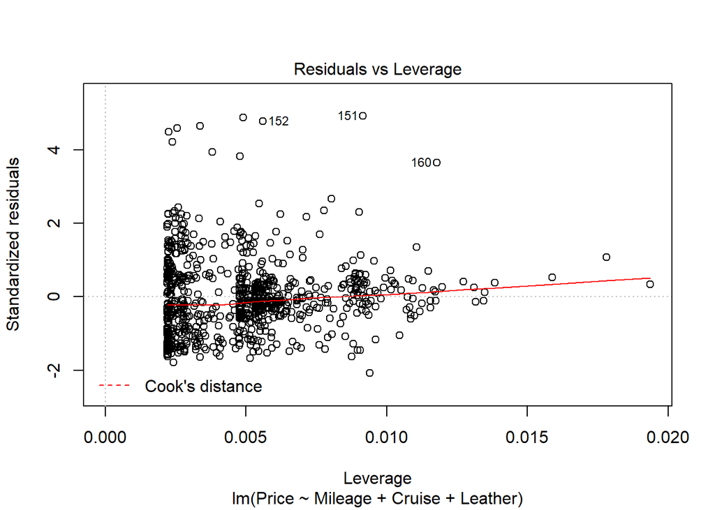

```r
> plot(fit2)
```

```r
> # We want our model to fits our data well, but especially want
> # a model that will make good predictions with *future* data.  In other
> # words, we want our model to generalize well.  To get an idea
> # of how our model will generalize, we split our data into
> # training and test data.
> #
> # split data into test and training sets using function 'split_data'
> # from the lin-regr-util.R file.  The second parameter of the function
> # shows how many files the data frame of the first parameter should
> # be split into, and their relative sizes.  In this usage the training/test
> # data sets use a 75/25 split.
> dsets = split_data(cars, c(3,1))
> tr_dat = dsets[[1]]
> te_dat = dsets[[2]]
```

```r
> #@ 9
> fit3 <- lm(Price ~ Mileage + Cruise + Leather, data = tr_dat)
```

### Predictions from training data and test data

Looking at prediction errors using the training data is not very useful. A model that has low error on training data could still have high error on test data. In this case we see the error on the test data is similar to the error on the training data. This suggests we’re not overfitting when we build our model.

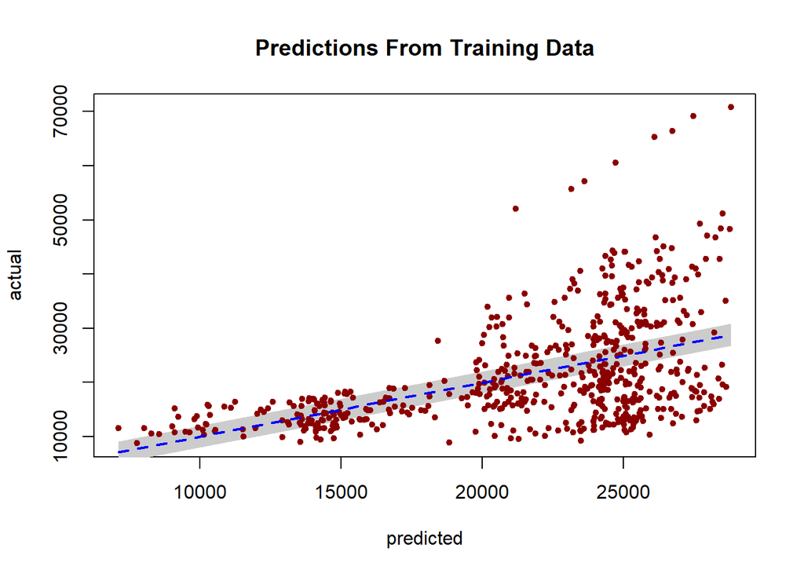

```r
> #@ 10
> predicted <- predict(fit3, tr_dat)
> actual <- tr_dat$Price
> plot_predict_actual(predicted, actual, 2000, "Predictions From Training Data")
```

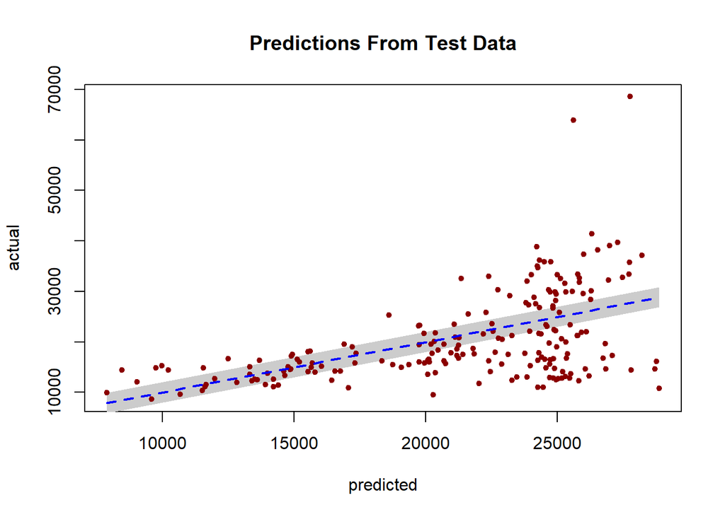

```r
> #@ 11
> predicted <- predict(fit3, te_dat)
> actual <- te_dat$Price
> plot_predict_actual(predicted, actual, 2000, "Predictions From Test Data")
```

```r
> #@ 12
> rmse = sqrt(mean((actual - predicted)^2))
```

The RMSE value computed from our test set confirms that our model is not yet very useful.

```r
> print(paste0("RMSE for Price prediction from Mileage, Cruise, Leather, on test data: ",
+              round(rmse)))
```

```
[1] "RMSE for Price prediction from Mileage, Cruise, Leather, on test data: 7749"
```

### Adding input feature cyl8 to the linear model

We add to our model a feature that indicates whether a car has an eight-cylinder engine.

```r
> #@ 13
> fit4 <- lm(Price ~ Mileage + Cruise + Leather + cyl8, data = tr_dat)
```

The R-squared statistic is improving. It looks like leather isn’t very useful for predicting price (at least, in the presence of the other features we’re using).

```r
> summary(fit4)
```

```
Call:
lm(formula = Price ~ Mileage + Cruise + Leather + cyl8, data = tr_dat)

Residuals:
     Min       1Q   Median       3Q      Max
-17242.3  -4057.3   -593.3   2997.1  28203.6

Coefficients:
              Estimate Std. Error t value Pr(>|t|)
(Intercept)  1.686e+04  9.818e+02  17.169  < 2e-16 ***
Mileage     -1.673e-01  3.279e-02  -5.102 4.53e-07 ***
Cruise       6.974e+03  6.475e+02  10.769  < 2e-16 ***
Leather      4.150e+02  6.344e+02   0.654    0.513
cyl8         1.841e+04  8.362e+02  22.010  < 2e-16 ***
---
Signif. codes:  0 '***' 0.001 '**' 0.01 '*' 0.05 '.' 0.1 ' ' 1

Residual standard error: 6605 on 597 degrees of freedom
Multiple R-squared:  0.5824,    Adjusted R-squared:  0.5796
F-statistic: 208.2 on 4 and 597 DF,  p-value: < 2.2e-16
```

The distribution of the residuals is improving, but it is still not very much like a normal distribution.

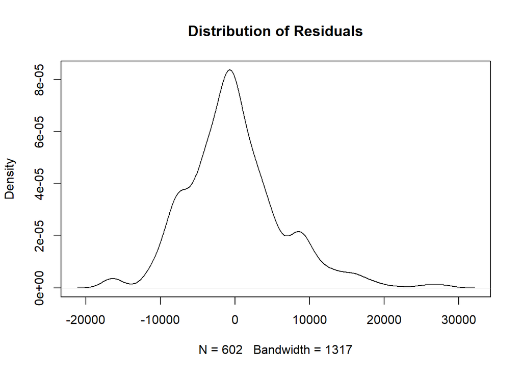

```r
> #@ 14
> plot(density(fit4$residuals), main = "Distribution of Residuals")
```

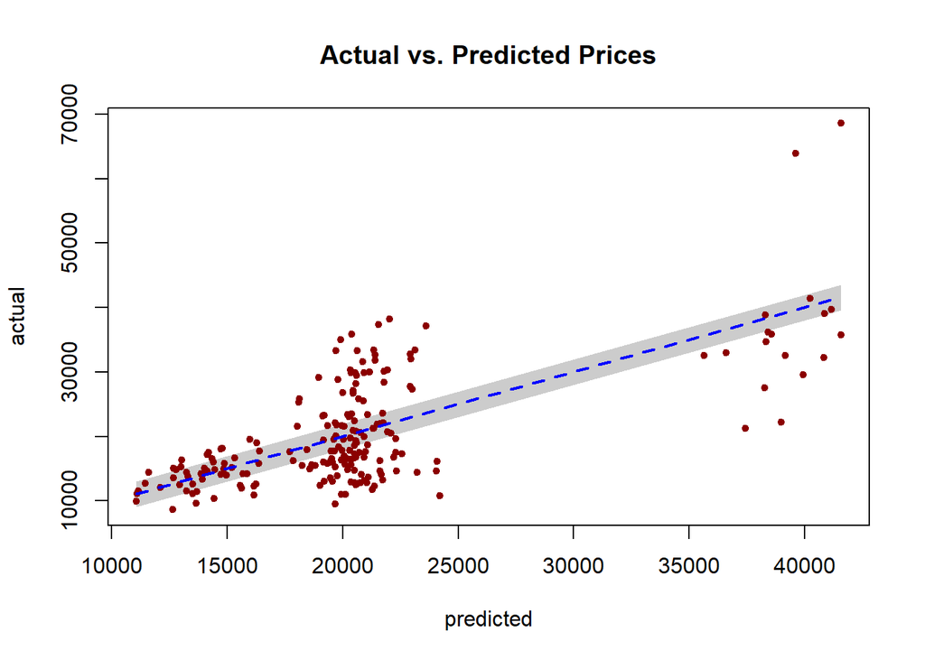

```r
> #@ 15
> predicted <- predict(fit4, te_dat)
> actual <- te_dat$Price
> plot_predict_actual(predicted, actual, 2000, "Actual vs. Predicted Prices")
```

### Using a validation data set

A problem is that we can’t use the test data to pick the “best” set of features, because then we can’t use the test data to give a fair idea of the how our model will do on future data.

We also can’t use the training data for this purpose, as we already know.

An alternative is to split our data set into *three* pieces, one for training, another (called the “validation” data set) for comparing alternative sets of features, and the last for doing the final test of our model.

A problem with splitting the data three ways is that the size of each of the three pieces is not very big. This means our validation results are not very reliable.

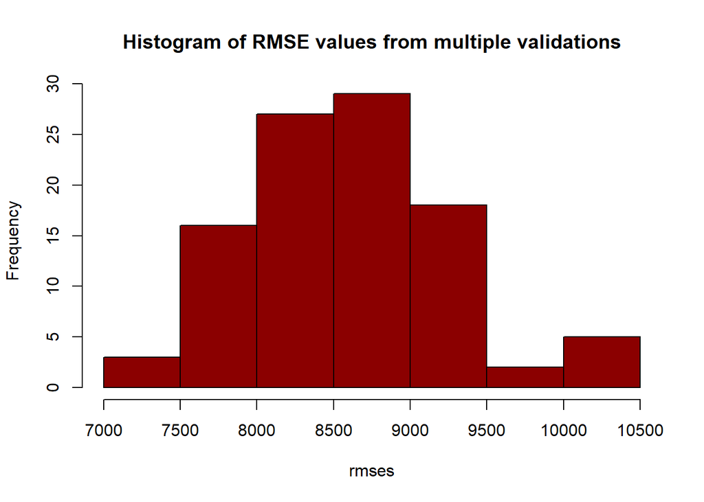

```r
> rmses = c()
> for (i in 1:100) {
+   dsets = split_data(cars, c(2, 1, 1))
+   train_dat = dsets[[1]]
+   valid_dat = dsets[[2]]
+
+   fit=lm(Price ~ Mileage + Cruise + Leather + Sound, data=train_dat)
+
+   #@ 16
+   predicted <- predict(fit, valid_dat)
+   actual <- valid_dat$Price
+   rmse <- sqrt(mean((actual - predicted)^2))
+
+   rmses = c(rmses, rmse)
+ }
>
> # Note the range of RMSE values that you get
> hist(rmses, col="red4", main="Histogram of RMSE values from multiple validations")
```

### Finding best features using cross validation

A way to get more reliable validation results is to “cross validate”, which basically allows the training data to be re-used. One cross validation method is called 10-fold cross validation. In this method you split the training data into 10 pieces. To see how well a set of features works, you train the model on 9 of the 10 pieces, and validate on the remaining piece. You then repeat this 9 more times, each time using a different subset of 9 of the 10 pieces. In each of the 10 validation runs, you compute a result, like the RMSE.

```r
> # The function "cross_validate_lm" in the file lin-regr-util.R does
> # cross validation for feature selection in linear regression.
> # if you run the following line of R code a bunch of times, you'll see
> # that the results are quite stable
>
> rmse_cv = cross_validate_lm(tr_dat, "Price", c("Mileage", "Cruise", "Leather", "Sound"))
> print(paste0("RMSE from cross validation: ",round(rmse_cv)))
```

```
[1] "RMSE from cross validation: 8684"
```

Notes on cross validation:

- Cross validation is used for all kinds of machine learning problems, not just feature selection in linear regression.
- Please read the cross_validate_lm code and understand how it works.
- There are special methods that allow for very cheap cross validation with linear regression. We’re using a general-purpose cross validation method here so that you can see the idea.

By computing RMSE for each single feature (using cross validation), we can find the single most effective feature in predicting price.

```r
> features = setdiff(names(cars), "Price")
>
> min_rmse = 100000
> for (feature in features) {
+   rmse = cross_validate_lm(tr_dat, "Price", feature)
+
+   #@ 17
+   # YOUR CODE HERE  (assign min_rmse and min_feature as required)
+   if(min_rmse > rmse)
+   {
+     min_rmse <- rmse
+     min_feature <- feature
+   }
+ }
>
> paste0("best feature to predict Price: '", min_feature, "'; RMSE = ", round(min_rmse))
```

```
[1] "best feature to predict Price: 'Model'; RMSE = 2386"
```

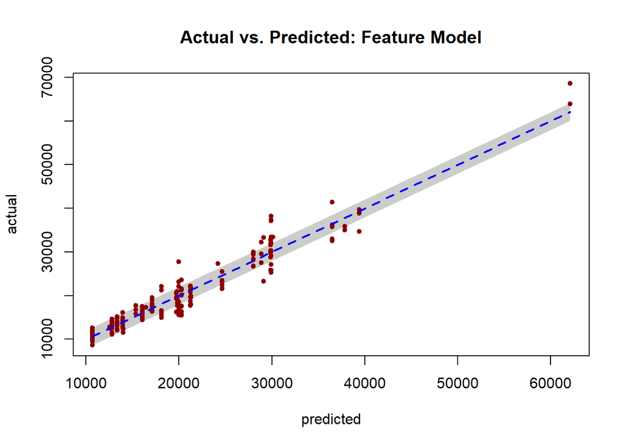

```r
> ff = reformulate(min_feature, "Price")
> fit = lm(ff, tr_dat)
>
> #@ 18
> predicted <- predict(fit, te_dat)
> actual <- te_dat$Price
>
> plot_predict_actual(predicted, actual, 2000, "Actual vs. Predicted: Feature Model")
```

```r
> # R-squared statistic is much better than before
> summary(fit)
```

```
Call:
lm(formula = ff, data = tr_dat)

Residuals:
     Min       1Q   Median       3Q      Max
-10111.5  -1237.3     -4.8   1177.1   8642.0

Coefficients:
                           Estimate Std. Error t value Pr(>|t|)
(Intercept)                16053.65    1031.93  15.557  < 2e-16 ***
ModelBuick Lacrosse         5239.12    1138.58   4.601 5.18e-06 ***
ModelBuick Lesabre          3757.24    1191.57   3.153 0.001700 **
ModelBuick Park Avenue      8595.65    1228.24   6.998 7.30e-12 ***
ModelCadillac CST-V        28969.28    1263.85  22.922  < 2e-16 ***
ModelCadillac CTS          14072.30    1287.04  10.934  < 2e-16 ***
ModelCadillac Deville      20467.74    1138.58  17.977  < 2e-16 ***
ModelCadillac STS-V6       21805.85    1315.45  16.577  < 2e-16 ***
ModelCadillac STS-V8       26930.80    1263.85  21.309  < 2e-16 ***
ModelCadillac XLR-V8       46059.86    1315.45  35.014  < 2e-16 ***
ModelChevrolet AVEO        -5375.62    1088.98  -4.936 1.05e-06 ***
ModelChevrolet Cavalier    -3272.36    1083.30  -3.021 0.002635 **
ModelChevrolet Classic     -2051.38    1315.45  -1.559 0.119446
ModelChevrolet Cobalt      -2097.96    1107.35  -1.895 0.058654 .
ModelChevrolet Corvette    23367.87    1182.22  19.766  < 2e-16 ***
ModelChevrolet Impala       3918.74    1143.19   3.428 0.000652 ***
ModelChevrolet Malibu       1057.33    1086.56   0.973 0.330920
ModelChevrolet Monte Carlo  4238.20    1148.22   3.691 0.000245 ***
ModelPontiac Bonneville     5157.71    1143.19   4.512 7.81e-06 ***
ModelPontiac G6             3677.45    1202.16   3.059 0.002325 **
ModelPontiac Grand Am       -684.25    1173.91  -0.583 0.560202
ModelPontiac Grand Prix     2040.61    1143.19   1.785 0.074792 .
ModelPontiac GTO           12794.70    1351.11   9.470  < 2e-16 ***
ModelPontiac Sunfire       -3524.32    1351.11  -2.608 0.009334 **
ModelPontiac Vibe             -5.92    1153.73  -0.005 0.995908
ModelSAAB 9-2X AWD          8133.96    1685.13   4.827 1.78e-06 ***
ModelSAAB 9_3              13080.68    1166.48  11.214  < 2e-16 ***
ModelSAAB 9_3 HO           13877.59    1120.28  12.388  < 2e-16 ***
ModelSAAB 9_5              13813.66    1148.22  12.030  < 2e-16 ***
ModelSAAB 9_5 HO           11965.84    1214.27   9.854  < 2e-16 ***
ModelSaturn Ion            -2690.99    1096.08  -2.455 0.014382 *
ModelSaturn L Series         411.60    1287.04   0.320 0.749236
---
Signif. codes:  0 '***' 0.001 '**' 0.01 '*' 0.05 '.' 0.1 ' ' 1

Residual standard error: 2307 on 570 degrees of freedom
Multiple R-squared:  0.9513,    Adjusted R-squared:  0.9487
F-statistic: 359.5 on 31 and 570 DF,  p-value: < 2.2e-16
```

Having found the single best feature, we can look for the best feature out of the remaining features. This is a kind of greedy algorithm for feature selection: we find the best feature, then the best of the remaining features, etc.

This approach is not guaranteed to find the two best features, however. Think of trying to find the best basketball team by finding the best basketball player, then the next-best basketball player, etc. The top five people may not work together to be the best team.

```r
> # Trim feature not used because of rank coefficient problems
> features = setdiff(names(cars), c("Price", "Trim", min_feature))
>
> #@ 19
> min2_rmse = 100000
> for (feature in features) {
+   rmse = cross_validate_lm(tr_dat, "Price", feature)
+   if(min2_rmse > rmse)
+   {
+     min2_rmse <- rmse
+     min2_feature <- feature
+   }
+ }
```

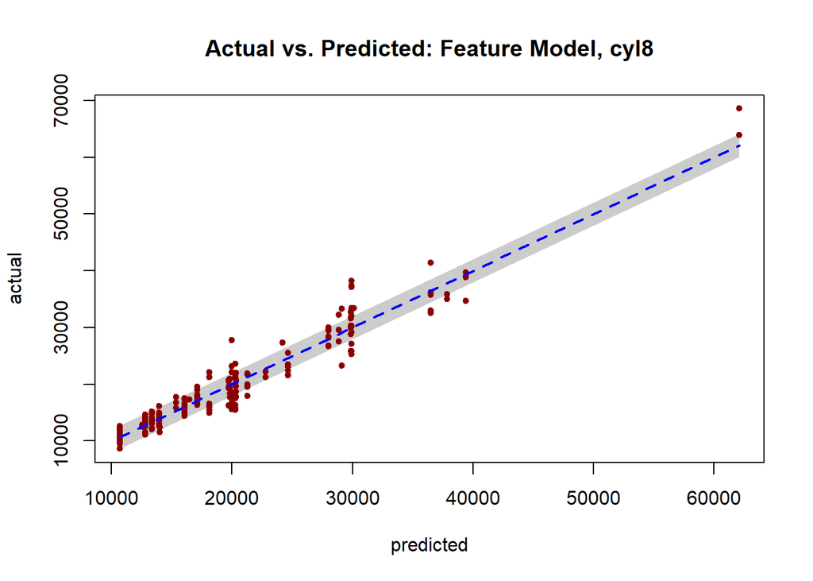

```r
> ff = reformulate(c(min_feature, min2_feature), "Price")
> fit = lm(ff, tr_dat)
>
> #@ 20
> predicted <- predict(fit, te_dat)
> actual <- te_dat$Price
>
> plot_predict_actual(predicted, actual, 2000, "Actual vs. Predicted: Feature Model, cyl8")
```

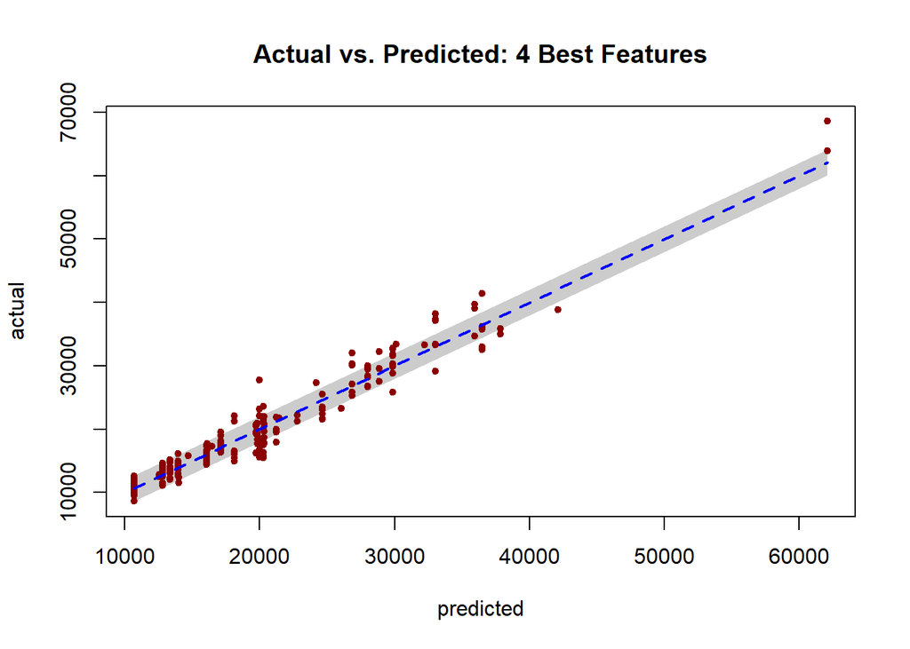

```r
> #@ 21
>
> # Trim feature not used because of rank coefficient problems
> features = setdiff(names(cars), c("Price", "Trim"))
> best_features = c()
> for (i in 1:4)
+ {
+   min_rmse = 100000
+   for (feature in features) {
+     rmse = cross_validate_lm(tr_dat, "Price", feature)
+     if(min_rmse > rmse)
+     {
+       min_rmse <- rmse
+       min_feature <- feature
+     }
+   }
+   best_features = c(best_features, min_feature)
+   features = setdiff(names(cars), c("Price", "Trim", best_features))
+ }
>
> ff = reformulate(best_features, "Price")
> fit = lm(ff, tr_dat)
> predicted <- predict(fit, te_dat)
> actual <- te_dat$Price
>
> plot_predict_actual(predicted, actual, 2000, "Actual vs. Predicted: 4 Best Features")
```